# Using Multinational Time Use Survey (MTUS) Data with `cleantimeuse`

Patrick Braga

Last updated July 5, 2020

## Overview

The `cleantimeuse` package was developed as part of Urban Stack, a research group within the Laboratory for Design Technologies at the Harvard University Graduate School of Design. The aim of the package is to facilitate using time use survey data to study transport and travel behavior. It cleans and prepares data retrieved from the Multinational Time Use Study Extract System:

Kimberly Fisher, Jonathan Gershuny, Sarah M. Flood, Daniel Backman and Sandra L. Hofferth. *Multinational Time Use Study Extract System*: Version 1.3 [dataset]. Minneapolis, MN: IPUMS, 2019. https://doi.org/10.18128/D062.V1.3

This document describes the structure and contents of IPUMS MTUS, the source of the international and intertemporal data. The overview descriptions are followed by a tutorial showing how to download the data and how to use the `cleantimeuse` package with R.

### What are IPUMS and MTUS?

- **IPUMS** “provides census and survey data from around the world integrated across time and space.” Originally, it meant “Integrated Public Use Microdata” and is now a platform that allows access to time use, public health, geospatial, environmental, and census data from different countries and time periods. IPUMS is hosted by the University of Minnesota and is supported by other entities, including University College London and the University of Maryland.
- **MTUS** stands for Multinational Time Use Survey. It is one of three time use data sets available from IPUMS. MTUS can be accessed either via https://timeuse.ipums.org/ or https://www.mtusdata.org/mtus/ and you will need to create a free account to download data.

### What data samples are available?

MTUS offers samples from Austria, Bulgaria, Canada, Finland, France, Hungary, Israel, Italy, Netherlands, South Africa, South Korea, Spain, the United Kingdom, and the United States. Most countries only have one or two years of data available. A few have pre-2000 data. MTUS harmonizes data across countries’ independent time use studies to facilitate comparative analysis. Variables are all named the same, and measurements such as income are normalized into quartiles to make them more comparable.

Descriptions of how the data were collected are available in a spreadsheet named **ipums_country_sample_comparison.xlsx** (in Taelor’s sandbox), which summarizes the Sample Descriptions on the IPUMS website.[^1] The website also has lengthy codebook documents that describe the survey process in the original language[^2].

### How are the data structured?

By default, data downloads will come with identifiers for individual respondents, household ID, and a “proposed” *survey weight*.[^3] Survey weights are inflation/deflation factors whose goal is to the sample data proportionately representative of the actual population. Depending on how the data were collected, it’s possible that one geography (e.g. the capital city) may have been overrepresented in the data relative to its actual proportion of the national population in real life. Functions from the survey package calculate different statistics taking these survey weights into account via so-called “complex survey objects” created by the as_survey_design function.

Data are available in two primary structures: *by person* and *by activity*. This distinction is important depending on the question you are trying to answer. You should download data in both formats; it’s required for the data-cleaning functions and allows you as the researcher to answer different kinds of questions.

**By-person data** is useful for calculating total time spent on an activity on a per-day basis. Each row in the data frame is an individual person over the course of a day. By-person data frames answer questions such as: how many total minutes did an individual work, travel, and so on? In by-person data, the IPUMS activity variables all sum to 1,440 minutes (24 hours). A full list of ACT_* variables is available as a tab in IPUMS_activity_codes.xlsx

**By-activity data** is useful for extracting counts of instances of activities across a day (e.g. how many trips did a person take?) and how long individuals spent on that activity. Each row is an activity that an individual performed; the MAIN column uses a code to identify the kind of activity (e.g. if MAIN == 63 then the person was commuting), and the TIME variable counts the number of minutes the person performed that activity. Note that the ACT_* variables in by-activity data extracts still summarize total time spent on an activity.

Depending on the sample extract (i.e., the country and year being analyzed), the data may also indicate multitasking via SEC (secondary activity). However, my code currently ignores multitasking, so you will need to write new code to analyze that.

## Using the `cleantimeuse` package

The `cleantimeuse` package, written originally for the Urban Stack research team at the Harvard Graduate School of Design, offers a suite of functions designed to make it easy to load and clean MTUS data for travel behavior research. The package can be loaded via the standard `library` command.

```r
library(cleantimeuse)
```

```r
if (!require(remotes)) install.packages("remotes")
remotes::install_github("mnpopcenter/ipumsr")
library(ipumsr) #this overrides the ipumsr call built into the `cleantimeuse` package
```

Below is a list of the primary user-facing functions and their associated internal functions. As with any other R package, users can obtain help and documentation with the `?` operator; the functions are documented in detail, and the user is encouraged to read the manual pages for the user-facing functions in particular.

```r
table_of_functions <- read.csv("example_data/mtus_table_of_functions.csv")
knitr::kable(table_of_functions)
```

| User_Facing | Internal |
| --- | --- |
| **`mtus_init_raw_data`** | `all_core_variables_are_in` |
| **`mtus_init_countries`** |  |
|  | `init_by_activity` `recode_internal` `mtus_load_country` `check_valid_country` `filter_to_country` `count_trips` |
| **`mtus_recode`** |  |
| **`def_survey_objects`** |  |

## Downloading data

1. Visit https://www.mtusdata.org/mtus/ and select “Get Data” under “Create an Extract.”
2. Navigate to “Select Samples” in the upper left and select any number of country/year combinations. Then click “Submit Sample Selections.”
3. Use the dropdown menus under “Select Variables” to choose the variables of interest. At the very least, beyond the pre-selected identifier (IDENT) and survey weight (PROPWT) variables, you should select the variables below. Any other variables for plotting or regression analysis will be the individual researcher’s choice.
- HLDID (Person – Technical Person) = household identifier
- AGE (Person – Core Demographic) = respondent age, used to filter observations only to working-age adults
- TIME (Activity – Episode Details) = the activity duration in minutes.
- ELOC (Activity – Episode Details) = location of activity (01 = at home, 03 = at workplace, 08 = traveling).
- ACT_WORK (Time Use – Activity Coding Structure) = total time in the day spent on working.
- MAIN (Activity – Episode Details) = code for activity. Refer to **MTUS_activity_codes.xlsx** for a comprehensive list.
- SEC (Activity – Episode Details) = code for second activity (useful for studying multitasking).
4. Use “Change Data Structure” to choose either Rectangular/Person or Rectangular/Activity structures.
5. Select “View Cart” at the upper right, and then select “Create Data Extract” after confirming you have all the needed variables.
6. Once the IPUMS servers have completed assembling the data into a downloadable file, you will receive an email notification. The data download will be available under the “My Data” page.
7. Select “Download .DAT” to download the .dat.gz file. Do not extract/unzip this file; move it directly to your working directory. Right-click “DDI” under “Codebook” and save it to your working directory as well.
8. Repeat steps 4 through 7 to download the remaining type of data structure (either by-person or by-activity). You will need both for the mtus packages to work.

## Preparing Data for Use

If needed, set R’s working directory to the relevant location. Markdown knitting already sets the source directory as the working directory, though, so we don’t need to run this line now.

```r
# setwd(getSrcDirectory()[1])
```

**Always load raw MTUS data first.**

First, here is an example of what happens if we didn’t select all the minimum required variables from the IPUMS website.

```r
by_person_data <- mtus_init_raw_data("example_data/mtus_00017.xml")
```

```
#> Use of data from IPUMS MTUS is subject to conditions including that users
#> should cite the data appropriately. Use command `ipums_conditions()` for more
#> details.
#> [1] "AGE"         "is present."
#> [1] "TIME"        "is missing."
#> [1] "ELOC"        "is missing."
#> [1] "ACT_WORK"    "is present."
#> [1] "MAIN"        "is missing."
#> [1] "You did not download all the basic variables. Please make sure your data extract includes AGE, TIME, ELOC, ACT_WORK, and MAIN at the very least."
```

For now, it’s actually ok that those variables are missing in the by-person data, so we can turn the checking feature off. We’ll leave it on for by-activity data, though, because that’s important.

```r
by_person_data <- mtus_init_raw_data("example_data/mtus_00017.xml",
                                     check = FALSE)
```

```
#> Use of data from IPUMS MTUS is subject to conditions including that users
#> should cite the data appropriately. Use command `ipums_conditions()` for more
#> details.
```

```r
by_activity_data <- mtus_init_raw_data("example_data/mtus_00016.xml")
```

```
#> Use of data from IPUMS MTUS is subject to conditions including that users
#> should cite the data appropriately. Use command `ipums_conditions()` for more
#> details.
#> [1] "AGE"         "is present."
#> [1] "TIME"        "is present."
#> [1] "ELOC"        "is present."
#> [1] "ACT_WORK"    "is present."
#> [1] "MAIN"        "is present."
#> [1] "All minimum required variables are present."
```

Note that we have `check=FALSE` turned on for the by-person data. This is because when I downloaded this data set, I deliberately omitted some of the variables that are required for the by-activity portion of the data. By setting `check=FALSE`, the computer won’t check whether I have the minimum required variables. Otherwise, R indicates which variables are missing.

## Using the prepared data

The `mtus_init_countries()` procedure can create data objects in three scenarios:

- for a single country-year sample (e.g. `"UK2014"`),
- for a character vector with multiple countries (e.g. `c("ZA2000", "ZA2010")` for South Africa),
- or for ever unique country-year sample in the data file (by calling `"all"`).

```r
mtus_init_countries(by_activity_data,
                    by_person_data,
                    "UK2014")
```

```
#> [1] "Loading data from UK2014"
```

```r
mtus_init_countries(by_activity_data,
                    by_person_data,
                    c("ZA2000","ZA2010"))
mtus_init_countries(by_activity_data, by_person_data, "all")
```

```
#> [1] "Loading variable names from by-person data."
#> [1] "Loading data from FI2009"
#> [1] "Loading data from FR2009"
#> [1] "Loading data from HU2009"
#> [1] "Loading data from KR2009"
#> [1] "Loading data from NL2005"
#> [1] "Loading data from ES2009"
#> [1] "Loading data from UK2014"
#> [1] "Loading data from ZA2000"
#> [1] "Loading data from ZA2010"
```

The MTUS functions also run a `check_valid_country()` function that confirms whether the user’s inputted country-year combination actually exists in the data set. For instance, there is no 2008 data for France, so if we try to load that, the function returns an error because there are no entries named “FR2008” in the column that identifies samples:

```r
mtus_init_countries(by_activity_data, by_person_data, "FR2008")
```

```
#>  [1] "Country/year mix not available. Please select from the following:"
#>  [2] "FI2009"
#>  [3] "FR2009"
#>  [4] "HU2009"
#>  [5] "KR2009"
#>  [6] "NL2005"
#>  [7] "ES2009"
#>  [8] "UK2014"
#>  [9] "ZA2000"
#> [10] "ZA2010"
```

### Loading only by-activity data

Sometimes we may want to filter solely by-activity data for a given country. To do this, we can use `mtus_init_countries()` and set `by_person_data = NULL`. Note that calling NULL here doesn’t affect any by-person data loaded earlier. The result of the procedure will be a variable preceded by `a_` to indicate by-activity.

```r
mtus_init_countries(by_activity_data, NULL, "UK2014")
```

```
#> [1] "a_variable name will be a_UK2014"
#> [1] "Loading by-activity data from UK2014"
```

As before, we can initialize the by-activity data for all countries at once.

```r
mtus_init_countries(by_activity_data, NULL, "all")
```

```
#> [1] "Loading variable names from by-activity data."
#> [1] "a_variable name will be a_FI2009"
#> [1] "Loading by-activity data from FI2009"
#> [1] "a_variable name will be a_FR2009"
#> [1] "Loading by-activity data from FR2009"
#> [1] "a_variable name will be a_HU2009"
#> [1] "Loading by-activity data from HU2009"
#> [1] "a_variable name will be a_KR2009"
#> [1] "Loading by-activity data from KR2009"
#> [1] "a_variable name will be a_NL2005"
#> [1] "Loading by-activity data from NL2005"
#> [1] "a_variable name will be a_ES2009"
#> [1] "Loading by-activity data from ES2009"
#> [1] "a_variable name will be a_UK2014"
#> [1] "Loading by-activity data from UK2014"
#> [1] "a_variable name will be a_ZA2000"
#> [1] "Loading by-activity data from ZA2000"
#> [1] "a_variable name will be a_ZA2010"
#> [1] "Loading by-activity data from ZA2010"
```

## Recoding data

First, users can recode activities and locations on the fly alongside the `mtus_init_countries` call, which uses pre-written CSV files with activity and location codes with their corresponding human-readable label.

```r
mtus_init_countries(by_activity_data, NULL, "FR2009",
                    recode_activities = TRUE, recode_locations = TRUE)
```

```
#> [1] "a_variable name will be a_FR2009"
#> [1] "Loading by-activity data from FR2009"
#> [1] "varname is" "FR2009"
#> [1] "type is character"
#> [1] "recoding main activities"
#> [1] "column index" "10"
#> [1] "recoding secondary activities"
#> [1] "column index" "11"
#> [1] "type is character"
#> [1] "recoding locations"
#> [1] "column index" "12"
#> [1] "Recoded columns will be accessible in the variable preceded by a_"
```

```r
# or as a shortcut:
mtus_init_countries(by_activity_data, NULL, "FR2009", TRUE, TRUE)
```

```
#> [1] "a_variable name will be a_FR2009"
#> [1] "Loading by-activity data from FR2009"
#> [1] "varname is" "FR2009"
#> [1] "type is character"
#> [1] "recoding main activities"
#> [1] "column index" "10"
#> [1] "recoding secondary activities"
#> [1] "column index" "11"
#> [1] "type is character"
#> [1] "recoding locations"
#> [1] "column index" "12"
#> [1] "Recoded columns will be accessible in the variable preceded by a_"
```

```r
read.csv("example_data/codes_locations.csv")
```

```
#>    ELOC          LABEL                   DESC
#> 1     1           home            At own home
#> 2     2   not_own_home      At another's home
#> 3     3      workplace           At workplace
#> 4     4         school              At school
#> 5     5 services_shops   At services or shops
#> 6     6  food_business At restaurant, bar etc
#> 7     7        worship    At place of worship
#> 8     8         travel             Travelling
#> 9     9          other        Other locations
#> 10   -8             na       Location unknown
```

In fact, when a user sets one of the `recode` options in `mtus_init_countries` to `TRUE`, the code effectively calls something like the following: `recoded_FR2009 <- mtus_recode(a_FR2009, "ELOC", "codes_locations.csv")`. Notice that unlike `mtus_init_countries` but like `mtus_init_raw_data`, `mtus_recode` *returns* a data object, so you must assign the output to a variable if you wish to store it. Alternatively, this also means that `mtus_recode` can be called within a tidyverse pipeline.

## Example plots using cleaned MTUS data

These example functions are also built into the `cleantimeuse` library and suggest the kinds of visualization that the package facilitates.

```
#> [1] "mtus_trip_density(FR2009"
```

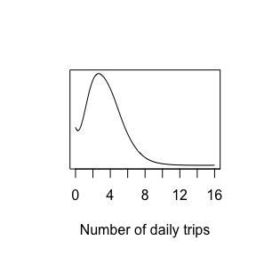

[figure not shown]

```
#> [1] "mtus_histogram(FR2009)"
```

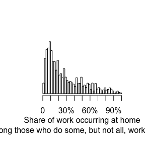

```
#> [1] "mtus_density(FR2009)"
```

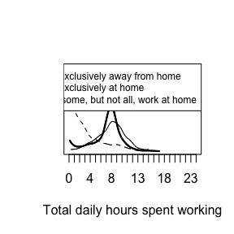

```
#> [1] "mtus_scatter(FR2009)"
```

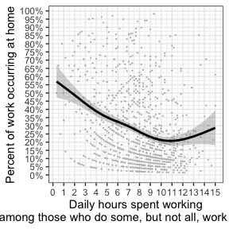

```
#> [1] "Loading data from NL2005"
```

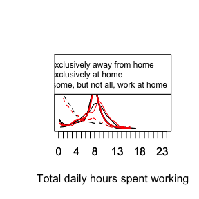

### Loading multiple countries

Suppose we want to load Spain, Finland, Hungary, and Korea data for 2009. We can create a character list of the countries we want, and use mtus_init_countries(…) – note that this is plural, rather than mtus_load_country(…). And unlike mtus_load_country, the function doesn’t have a return object, so we don’t need to create individual variables ahead of time.

```r
my_countries <- c("ES2009", "FI2009", "HU2009", "KR2009")
mtus_init_countries(by_activity_data,
                    by_person_data,
                    my_countries)
```

We can now deploy these immediately, such as in these overlay graphs: first is Spain (black) and Finland (red), followed by Hungary (black) and Korea (red).

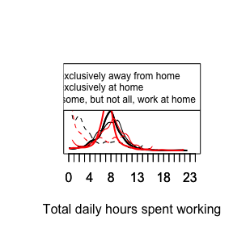

```r
mtus_density_ov(ES2009, FI2009)
```

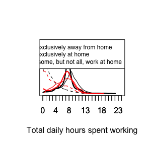

```r
mtus_density_ov(HU2009, KR2009)
```

[^1]: mtusdata.org/mtus/samples.shtml
[^2]: mtusdata.org/mtus/source_documents.shtml
[^3]: For more information on why survey weights are important, see youtube.com/watch?v=8iMV7ei61IM or youtube.com/watch?v=SJRVxvdIc8s
[^4]: https://forum.ipums.org/t/error-in-r-data-read/3573/2